# DATA 308: Lab 4a Solutions

Simple linear regression

Author

Your name here

Lab 4a was just 6 questions from lecture 4a slides that we did in class together. I added repeated them here for people that missed class.

```r
library(janitor)
library(tidyverse)
```

# Prerequisite knowledge

## Q1

Suppose our response variable was GPA and we have 6 observations: 4.0, 3.5, 3.0, 3.0, 2.5, 2.0

For this data identify:

- $Y_3$ = ?
- $\sum_{i = 1}^{n}Y_i$ = ?
- $\bar{Y}$ = ?
- $\sum_{i = 1}^{n} (Y_i - \bar{Y})^2$ = ?

### Solution

$$Y_3 = 3.$$

$$\begin{equation*}
\begin{split}
\sum_{i = 1}^{n}Y_i &= Y_1 + Y_2 + Y_3 + Y_4 + Y_5 + Y_6\\
&= 4 + 3.5 + 3 + 3 + 2.5 + 2\\
&= 18.
\end{split}
\end{equation*}$$

$$\begin{equation*}
\begin{split}
\bar{Y} &= \frac{1}{n}\sum_{i=1}^{n} Y_i\\
&= \frac{1}{6} (Y_1 + Y_2 + Y_3 + Y_4 + Y_5 + Y_6)\\
&= (4 + 3.5 + 3 + 3 + 2.5 + 2) / 6\\
&= 3.
\end{split}
\end{equation*}$$

$$\begin{equation*}
\begin{split}
\sum_{i = 1}^{n} (Y_i - \bar{Y})^2 &= (Y_1 - \bar{Y})^2 + (Y_2 - \bar{Y})^2 + (Y_3 - \bar{Y})^2 + (Y_4 - \bar{Y})^2 + (Y_5 - \bar{Y})^2 + (Y_6 - \bar{Y})^2 \\
&= (4 - 3)^2 +(3.5 - 3)^2 + (3 -3)^2 + (3-3)^2 + (2.5 - 3)^2 + (3-2)^2 \\
&= 2.5.
\end{split}
\end{equation*}$$

## Q2

Identify slope and $y$-intercept for these lines:

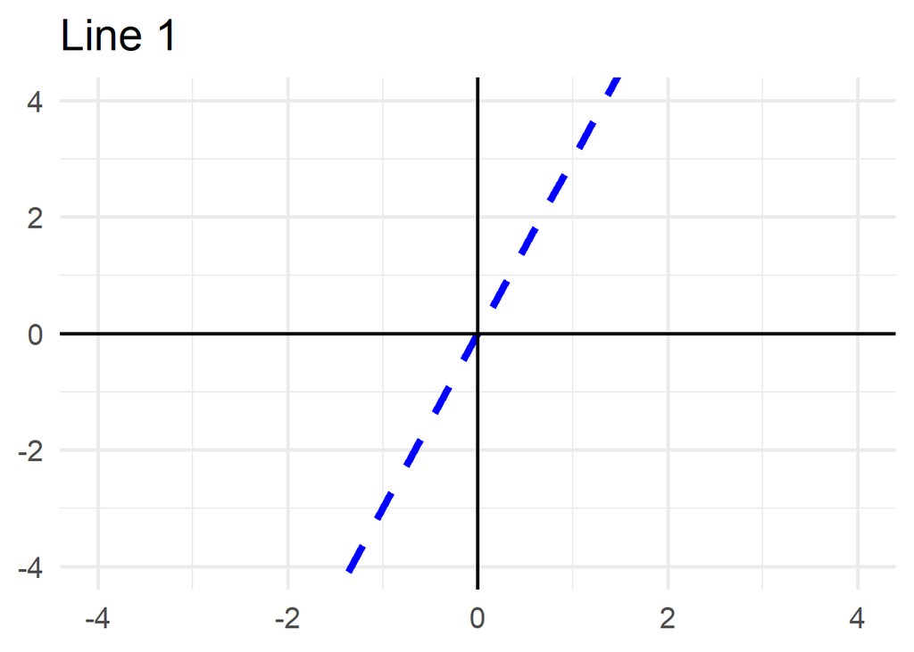

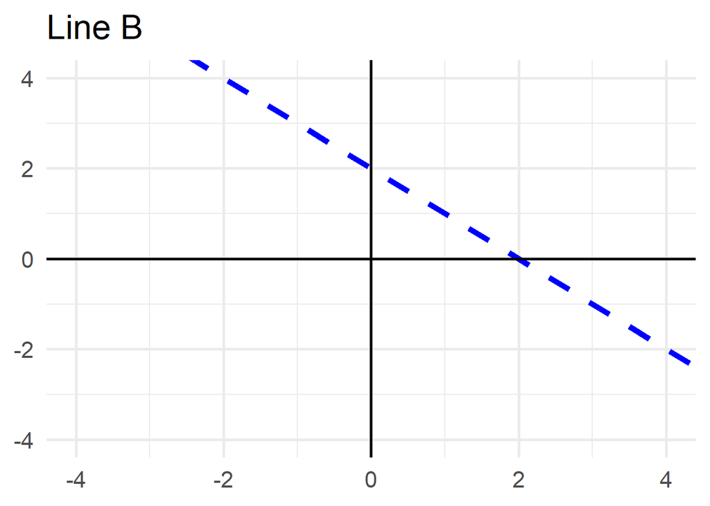

### Solution

# Elephant mass modeling

```r
elephants <- read_csv(
  "http://csuci-data308-fa26.github.io/course-materials/data/elephants.csv"
) |>
  clean_names()

glimpse(elephants)
```

```
Rows: 1,470
Columns: 5
$ sex    <chr> "B", "B", "B", "B", "B", "B", "B", "B", "B", "B", "B", "B", "B"…
$ age    <dbl> 58.96235, 59.03901, 59.12389, 59.29090, 59.37303, 59.45791, 59.…
$ chest  <dbl> 359, 359, 359, 361, 360, 359, 361, 357, 360, 364, 355, 355, 325…
$ height <dbl> 252, 252, 252, 253, 255, 254, 255, 256, 254, 255, 251, 257, 258…
$ mass   <dbl> 3244, 3182, 3239, 3336, 3317, 3357, 3358, 3155, 3334, 3357, 324…
```

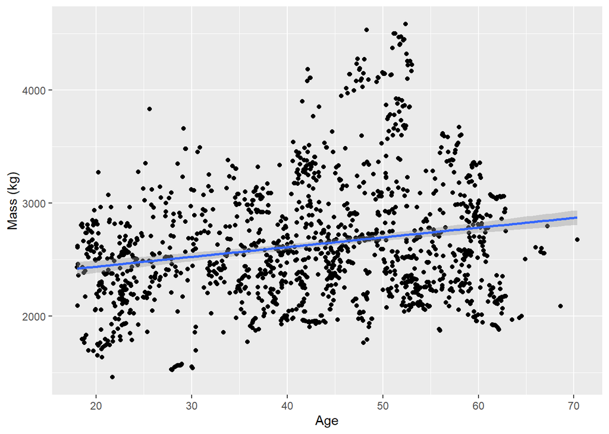

```r
ggplot(elephants, aes(x = age, y = mass)) +
  geom_point() +
  geom_smooth(method = "lm") +
  labs(x = "Age", y = "Mass (kg)")
```

```r
elephant_model <- lm(mass ~ age, data = elephants)
summary(elephant_model)
```

```
Call:
lm(formula = mass ~ age, data = elephants)

Residuals:
    Min      1Q  Median      3Q     Max
-994.26 -372.14  -64.44  267.67 1865.28

Coefficients:
            Estimate Std. Error t value Pr(>|t|)
(Intercept) 2264.678     48.213  46.972  < 2e-16 ***
age            8.629      1.089   7.926 4.44e-15 ***
---
Signif. codes:  0 '***' 0.001 '**' 0.01 '*' 0.05 '.' 0.1 ' ' 1

Residual standard error: 526.9 on 1468 degrees of freedom
Multiple R-squared:  0.04104,   Adjusted R-squared:  0.04038
F-statistic: 62.82 on 1 and 1468 DF,  p-value: 4.442e-15
```

## Q3

Identify and interpret the estimated intercept in context.

### Solution

The following would all be valid interpretations:

- We estimate the mass of 0 year old elephants to be 2264.7 kilograms, on average.
- 0 year old elephants are *expected* to have a mass of 2264.7 kilograms.

*Remember: expectation = long-run average!*

The intercept does not have a meaningful interpretation in this context, since we don’t care or know about mass for 0 year old elephants.

## Q4

Identify and interpret the estimated slope in context.

### Solution

The following would all be valid interpretations:

- For elephants differing in age by 1 year, we estimate the older elephants to have a mass of 8.6 kilograms more, on average.
- We estimate an higher mass of 8.6 kilograms to be associated with a 1 year increase in age, for elephants, on average.

## Q5

What mass would we predict, on average, for an elephant 30 years of age?.

### Solution

```r
2264.678 + 8.629 * 30
```

```
[1] 2523.548
```

## Q6

What mass would we predict, on average, for an elephant 6 years of age?.